# GEOG 4023/5023: Advanced Quant Methods for Geographic Data

Lab 6: Logistic Regression

Jason Lee

Please complete the following questions and submit the finished Rmd and HTML file onto Canvas.

Don’t forget to change name field in the beginning to your **first and last name**.

## Objectives

- Learn how to make maps with `ggplot`
- Understand how to use logistic regression in practices
- Understand the performance metrics of logistic regression
- Understand the variable selections in logistic regression
- Understand the diagnostics and assumptions of logistic regression

## Introduction

In this lab, we will review basics of logistic regression and apply it to a problem in spatial settings. We will try to map the landslide susceptibility with the help of auxiliary geographic and geomorphologic variables, e.g., elevation and slope. It is based on a study of landslide locations in Southern Ecuador: Muenchow, Brenning, and Richter (2012).

## Data

The data containing the landslide points, with the corresponding terrain attributes (`landslides.rds` in the enclosed `Data` folder), and geographic boundary of the study area (`boundary.shp`), along with the terrain attribute raster stack from which the values were extracted (`terrain.rds`). The terrain attributes includes the following:

- `slope`: slope angle (unit: degree).
- `cplan`: plan curvature (rad $m^{−1}$) expressing the convergence or divergence of a slope and thus water flow. See [this link](https://www.esri.com/arcgis-blog/products/product/imagery/understanding-curvature-rasters/) you are interested in knowing more about plan curvature
- `cprof`: profile curvature (rad $m^{−1}$) as a measure of flow acceleration, also known as downslope change in slope angle. See [this link](https://www.esri.com/arcgis-blog/products/product/imagery/understanding-curvature-rasters/) you are interested in knowing more about plan curvature
- `elev`: elevation (m) as the representation of different altitudinal zones of vegetation and precipitation in the study area.
- `log10_carea`: the decadic logarithm of the catchment area ($log_{10}m^2$) representing the amount of water flowing towards a location.

## Setup

We will use the package `ggplot2` for the mapping (feel free to use other packages too, such as `ggmap` or `tmap`; see the pages 63-76 in the enclosed slides). We will use `sf` for the reading and writing of files. Similar as the multiple regression lab of last week, we will primarily rely on `glm()` for the logistic regression this lab, which doesn’t need extra package. Let’s first load the library and related GIS library. If you have not installed it on your computer, please install by command `install.packages()` or the bottom right menu in `RStudio`. Feel free to use other libraries too.

```r
library(ggplot2)
library(sf)
library(maptools)
library(maps)
library(raster)
library(ggsn)
```

## Mapping

Let’s first load the data and take a look at what the data look like.

```r
# load the boundary of study area
boundary=st_read("Data/boundary.shp")
# check the data type
class(boundary)
```

```
## [1] "sf"         "data.frame"
```

```r
# load the landsldies points
landslides=readRDS("Data/landslides.rds")
# check the data types
class(landslides)
```

```
## [1] "data.frame"
```

```r
# see the information of the data frame
str(landslides)
```

```
## 'data.frame':    350 obs. of  8 variables:
##  $ x          : num  715078 713748 712508 713998 714308 ...
##  $ y          : num  9558647 9558047 9558887 9558187 9557307 ...
##  $ lslpts     : Factor w/ 2 levels "FALSE","TRUE": 1 1 1 1 1 1 1 1 1 1 ...
##  $ slope      : num  37.4 41.7 20 45.8 41.7 ...
##  $ cplan      : num  0.02051 -0.02405 0.03903 -0.00632 0.04235 ...
##  $ cprof      : num  0.00866 0.00679 0.01475 0.00435 -0.02024 ...
##  $ elev       : num  2477 2486 2142 2391 2570 ...
##  $ log10_carea: num  2.61 3.07 2.29 3.83 2.7 ...
```

```r
# load the terrain attributes
terrain <- readRDS("Data/terrain.rds")
# check the data types
class(terrain)
```

```
## [1] "RasterStack"
## attr(,"package")
## [1] "raster"
```

```r
 # check the dimension of terrain, we can see that there are 5 layers of rasters
dim(terrain)
```

```
## [1] 415 383   5
```

```r
 # check the names of each layer
names(terrain)
```

```
## [1] "slope"       "cplan"       "cprof"       "elev"        "log10_carea"
```

As we can see that the variable `landslides` is a data frame with x and y coordinates and the associated terrain attribute measurements in the location, and `terrain` is a `rasterstack` with 5 raster layers of different terrain attributes that the `landslides` extracted the attributes from. The `landslides` has a column `lslpts`, a logical variable indicating the presences or absence of landslides at each location.

## Mapping

Now let’s use `ggplot2` to map the data out and see how they look like. `ggplot2` works well with the data type of `data.frame`. Here the `boundary` is a `sf data.frame` that can be mapped with `geom_sf()` and `landslides` is a regular `data.frame` that can be visualized with `geom_point()`. See the following:

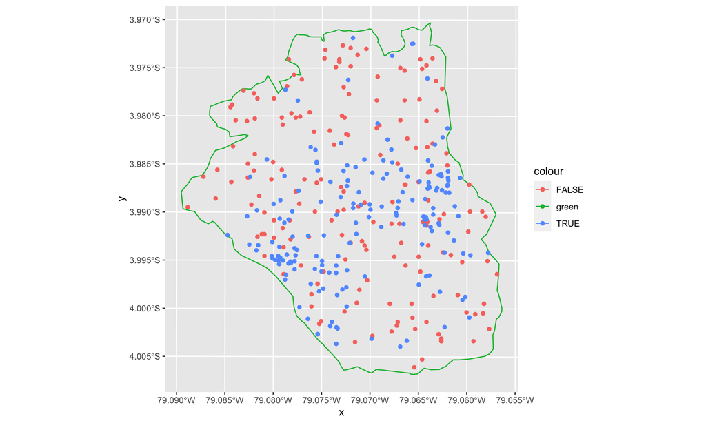

```r
ggplot() +
    geom_sf(data=boundary, aes(color='green')) +
    geom_point(data= landslides, aes(x =x, y=y, color=lslpts))
```

The `terrain` is in `rasterstack` data type. To map it with `ggplot`, we need to convert it to a `data.frame`. The `elev` layer can be mapped with the following codes:

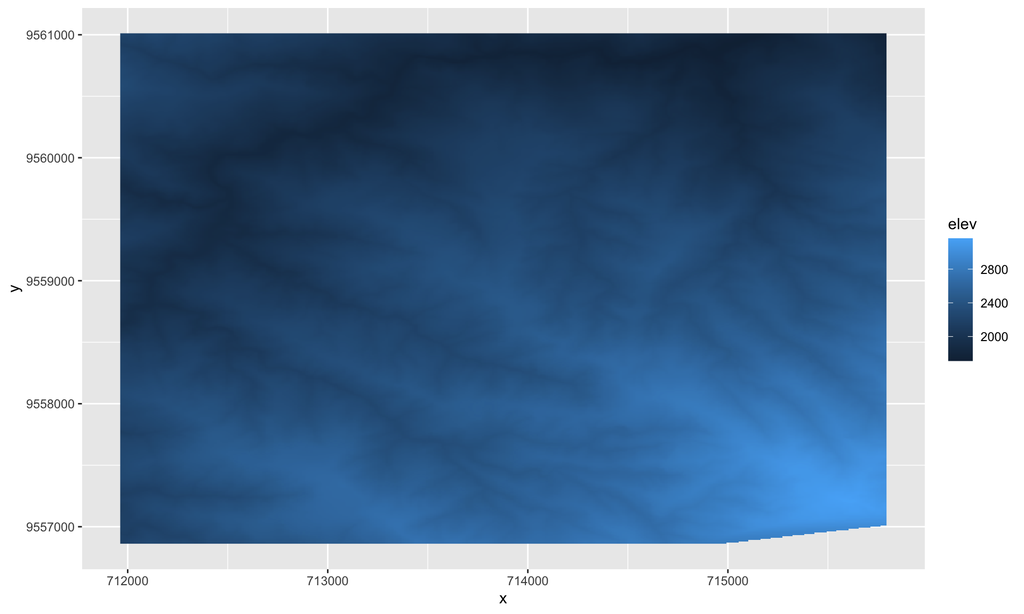

```r
terrain.df=as.data.frame(terrain, xy=T, na.rm=T)

ggplot() +
    geom_raster(data=terrain.df, aes(x=x, y=y, fill=elev))
```

We can change the color scale to make it look better. The package `RColorBrewer` provides set of ready-to-use color scheme that can be displayed:

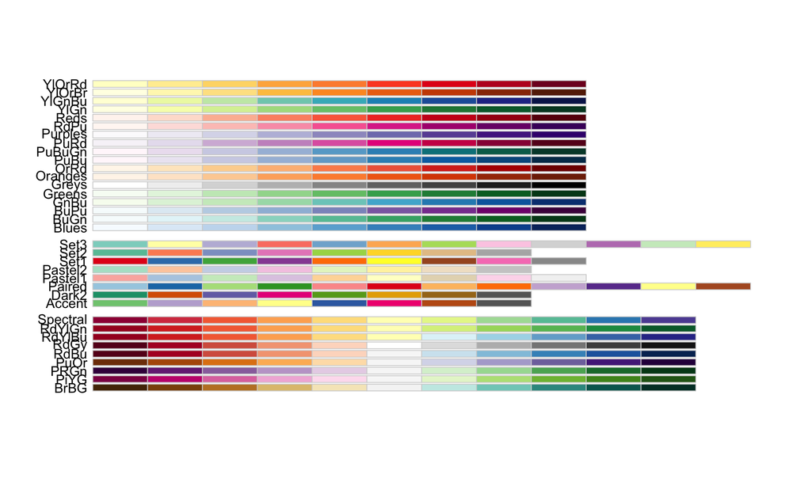

```r
library(RColorBrewer)
display.brewer.all()
```

The first set of color palettes are *sequential* palettes and are suitable for a variable that has ordinal meaning: elevation, temperature, precipitation, etc. The second set of palettes are *qualitative* palettes and suitable for qualitative or categorical data. Finally, the third set of palettes are *diverging* palettes and can be suitable for variables that take both negative and positive values like changes in groundwater level.

We can change the color scale of the previous rater map to `OrRd` palette:

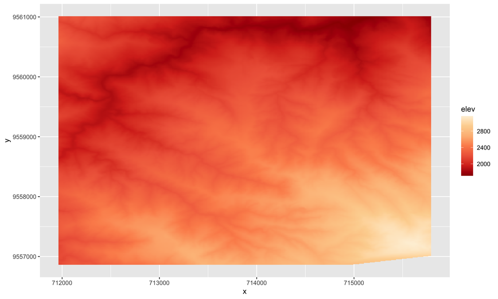

```r
ggplot() +
    geom_raster(data=terrain.df, aes(x=x, y=y, fill=elev)) +
      scale_fill_distiller(palette = "OrRd")
```

**Q1:** Please make a map by overlaying the landslides points and the boundary of study area on the `slope` layer of the `terrain` rasterstack . Note that not every point has presences of landslides (as indicated by `lslpts`), please differentiate presences and absences with different colors or symbols in the map. Please also adjust the color ramp to fit your taste of color scheme. (10 pts)

**Your answer:**

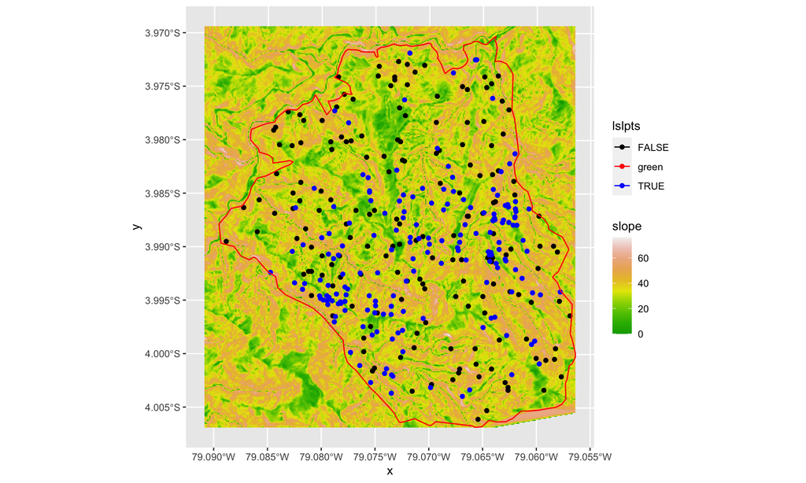

```r
# please type your codes here:
terrain_df = as.data.frame(terrain, xy = T, na.rm = T)

ggplot() +
  geom_raster(data = terrain_df, aes(x = x, y = y, fill = slope)) +
  scale_fill_gradientn(colors = terrain.colors(10)) +
  geom_point(data = landslides, aes(x = x, y = y, color = lslpts), size = 1.5) +
  geom_sf(data = boundary, aes(color = 'green')) +
  scale_color_manual(values = c("black", "red", "blue"))
```

## Logistic regression

We are interested in what terrain variables will contribute to the presences of the landslides (`lslpts`) and how. Many approaches are available for this purpose from different perspectives. In regression settings, logistic regression is perhaps one of the most commonly used method for binary response variable. We talked about it in the class a couple of weeks ago (see page 39 of the enclosed slides). Logistic regression belongs to the family of generalized linear models (GLM) that primarily deal with non-Gaussian response variables. Another commonly used GLM is Poisson regression for number of events (e.g., trees, crimes).

Let’s start with a full model:

```r
fitFull = glm(lslpts ~ slope + cplan + cprof + elev + log10_carea,
          family = binomial(),
          data = landslides)
summary(fitFull)
```

```
##
## Call:
## glm(formula = lslpts ~ slope + cplan + cprof + elev + log10_carea,
##     family = binomial(), data = landslides)
##
## Deviance Residuals:
##     Min       1Q   Median       3Q      Max
## -2.1999  -0.8352   0.1025   0.8220   2.6895
##
## Coefficients:
##               Estimate Std. Error z value Pr(>|z|)
## (Intercept)  1.967e+00  2.041e+00   0.963    0.335
## slope        9.295e-02  1.644e-02   5.655 1.56e-08 ***
## cplan       -2.570e+01  4.326e+00  -5.941 2.83e-09 ***
## cprof       -1.430e+01  1.116e+01  -1.281    0.200
## elev         2.408e-05  5.255e-04   0.046    0.963
## log10_carea -2.124e+00  4.450e-01  -4.772 1.82e-06 ***
## ---
## Signif. codes:  0 '***' 0.001 '**' 0.01 '*' 0.05 '.' 0.1 ' ' 1
##
## (Dispersion parameter for binomial family taken to be 1)
##
##     Null deviance: 485.20  on 349  degrees of freedom
## Residual deviance: 361.11  on 344  degrees of freedom
## AIC: 373.11
##
## Number of Fisher Scoring iterations: 5
```

**Q2:** As you can see that the full model has several insignificant variables. Please try to improve the full model (call it `fitSmall`) with a set of variables that are statistically significant and you think most relevant to the presences of landslides (`lslpts`). Please also show why the model (`fitSmall`) is better than the full model (`fitFull`)? *Hint* You can manually select the variables (with trial and error) or use the `step()`. (20 pts)

**Your answer:**

```r
# please type your codes here:
fitSmall <- glm(lslpts ~ slope + elev + log10_carea,
                family = binomial(),
                data = landslides)
summary(fitSmall)
```

```
##
## Call:
## glm(formula = lslpts ~ slope + elev + log10_carea, family = binomial(),
##     data = landslides)
##
## Deviance Residuals:
##      Min        1Q    Median        3Q       Max
## -2.00267  -1.08115   0.09228   0.99109   2.12226
##
## Coefficients:
##              Estimate Std. Error z value Pr(>|z|)
## (Intercept) -4.861650   1.623473  -2.995  0.00275 **
## slope        0.102802   0.014959   6.872 6.32e-12 ***
## elev         0.000597   0.000481   1.241  0.21451
## log10_carea -0.251051   0.280957  -0.894  0.37156
## ---
## Signif. codes:  0 '***' 0.001 '**' 0.01 '*' 0.05 '.' 0.1 ' ' 1
##
## (Dispersion parameter for binomial family taken to be 1)
##
##     Null deviance: 485.20  on 349  degrees of freedom
## Residual deviance: 415.85  on 346  degrees of freedom
## AIC: 423.85
##
## Number of Fisher Scoring iterations: 4
```

```r
AIC(fitFull)
```

```
## [1] 373.1144
```

```r
AIC(fitSmall)
```

```
## [1] 423.8454
```

Cross-validation is a commonly used approach to evaluate the estimation performance of a model. We talk about it in the lecture (please see page 7 of the enclosed slides). Simply put, cross-validation separates the measurements into groups, one of the groups selected as a validation group and the rest as training groups to train the model. The trained model is then used to make estimations for validation group. By looking at the discrepancies between the original measurements and the estimation of the validation group, we can have a measure of the estimation error. Two cross-validation types are often used: leave-one-out cross-validation (LOOCV) or k-fold cross-validation.

Cross-validation for GLM can be conducted using `cv.glm()` provided in the package `boot` (install by `install.packages('boot')`). For the full model, e.g., the estimation error can be obtained by:

```r
library(boot)
# leave one-out cross valiation
cvFull <- cv.glm(data=landslides, fitFull)
# estimation error
cvFull$delta[1]
```

```
## [1] 0.1768414
```

```r
# k-fold, k=10
cvFull <- cv.glm(data=landslides, fitFull, K=10)
cvFull$delta[1]
```

```
## [1] 0.1778396
```

**Q3:** Please conduct the cross-validation for `fitSmall` based on the above codes (using both methods) and compare the performances of the two model (`fitFull` and `fitSmall`) (20 pts)

**Your answer:**

```r
# please type your codes here
# Conducting leave-one-out cross validation for fitSmall
cvSmall_loo <- cv.glm(data=landslides, fitSmall, K = nrow(landslides))
# Estimation error
cvSmall_loo$delta[1]
```

```
## [1] 0.2094479
```

```r
# Conducting k-fold cross validation for fitSmall, k = 10
cvSmall_kfold <- cv.glm(data=landslides, fitSmall, K = 10)
# Estimation error
cvSmall_kfold$delta[1]
```

```
## [1] 0.210492
```

```r
# Comparing the performance of the two models
# Full model (fitFull)
cvFull_loo <- cv.glm(data=landslides, fitFull, K = nrow(landslides))
# Estimation error
cvFull_loo$delta[1]
```

```
## [1] 0.1768414
```

```r
cvFull_kfold <- cv.glm(data=landslides, fitFull, K = 10)
# Estimation error
cvFull_kfold$delta[1]
```

```
## [1] 0.1779436
```

Like in multiple regression, prediction can be made for the un-sampled locations based on the logistic regression model. For non-spatial cases, the function `predict()` can be used for the prediction. For this lab, the explanatory variables are all raster images. The `raster` package provide a convenient function `raster::predict()` to produce an estimation map based on the raster layers.

**Q4:** Please read the help doc of `raster::predict()` and make a prediction map of the study area (make sure you specify `type='response'` when using this prediction function). Please map the prediction results and explain what the values of the prediction map means. (20 pts)

**Your answer:**

[figure not shown]

```r
# Please type your codes here:
# load the landslides points
landslides <- readRDS("Data/landslides.rds")

# create binary response variable indicating presence or absence of landslides
landslides$lslpts <- ifelse(is.na(landslides$lsl), 0, 1)

# convert terrain object to RasterStack if not already
if (!is(terrain, "RasterStack")) {
  terrain <- stack(terrain)
}

# extract terrain attributes from terrain raster stack at landslide locations
slides <- SpatialPointsDataFrame(coordinates(landslides), data.frame(lslpts=as.numeric(landslides$lslpts)))
predictors <- raster::extract(terrain, slides, method="simple")

# combine response and predictor variables into a single data frame
data <- cbind(landslides["lslpts"], predictors)

# fit logistic regression model
model <- glm(lslpts ~ ., data=data, family=binomial)

# generate prediction map
if (!is(terrain, "RasterStack")) {
  terrain <- stack(terrain)
}
prediction <- raster::predict(terrain, model, type='response')

# convert prediction to data frame
pred_df <- as.data.frame(prediction)
names(pred_df) <- c("value")

# add x and y coordinates as columns
pred_df$x <- coordinates(terrain)[,1]
pred_df$y <- coordinates(terrain)[,2]

# plot the prediction map
ggplot(data=pred_df, aes(x=x, y=y, fill=value)) +
  geom_raster() +
  scale_fill_gradient(low='white', high='red') +
  theme_void() +
  theme(legend.position='bottom') +
  labs(title='Landslide Susceptibility Prediction Map')
```

**Q5:** Based on the prediction results, please map the areas with values larger than 0.5 and overlay the map with the landsldies points (differentiate the points with presences or not). Please comment on your findings. (20 pts)

[figure not shown]

```r
# please type your codes here:
# identify cells with predicted probability > 0.5
pred_df_sub <- pred_df[pred_df$value > 0.5, ]

# plot the prediction map with landslides
ggplot() +
  geom_raster(data=pred_df, aes(x=x, y=y, fill=value)) +
  geom_point(data=landslides, aes(x=x, y=y, color=factor(lslpts)), size=1.5) +
  geom_point(data=pred_df_sub, aes(x=x, y=y), color="red", size=1.5) +
  scale_fill_gradient(low='white', high='red') +
  scale_color_manual(values=c("black", "red")) +
  theme_void() +
  theme(legend.position='bottom') +
  labs(title='Landslide Susceptibility Prediction Map')
```

**Q6:** Please explain under what assumptions that logistic regression works. Are these assumptions satisfied for this case of landslides susceptibility mapping? What methods can be used to check if the assumptions are satisfied? (10 pts)